# R Notebook

Loading the dataset and calling the required libraries.

```r
data=read.csv("../datasets/data.csv")
library(TDA)
library(igraph)
library(erer)
```

Creating a graph of Indian states. The states are the vertices and there is an edge between two vertices if the corresponding states share a boundary.

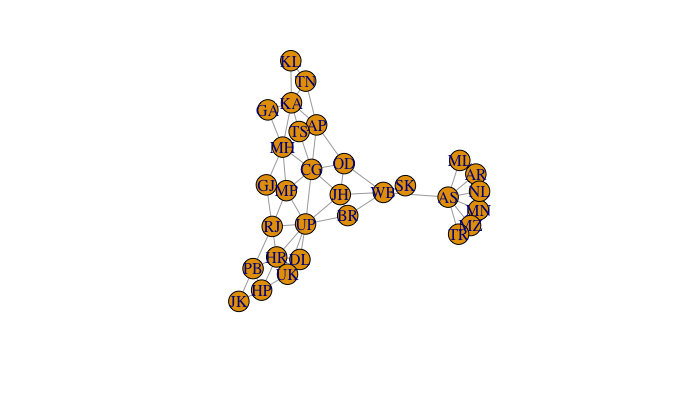

```r
indian_state_graph = make_empty_graph(n=0, directed = FALSE)
state_names = c("AP", "AR", "AS", "BR", "CG", "DL", "GA", "GJ", "HR", "HP", "JK", "JH", "KA", "KL", "MP", "MH", "MN", "ML", "MZ", "NL", "OD", "PB", "RJ", "SK", "TN", "TS", "TR", "UP", "UK", "WB")
indian_state_graph = add_vertices(indian_state_graph, 30, label = state_names)
indian_state_graph = add_edges(indian_state_graph, c(1,25, 1,13, 1,26, 1,5, 1,21, 2,3, 2,20, 3,20, 3,17, 3,19, 3,27, 3,18, 3,30, 4,30, 4,12, 4,28, 5,12, 5,21, 5,26, 5,16, 5,15, 5,28, 6,28, 6,9, 7,16, 7,13, 8,23, 8,15, 8,16, 9,10, 9,28, 9,23, 9,22, 10,11, 10,29, 10,22, 11,22, 12,30, 12,21, 12,28, 13,16, 13,26, 13,25, 13,14, 14,25, 15,28, 15,16, 15,23, 16,26, 17,20, 17,19, 19,27, 21,30, 22,23, 23,28, 24,30, 28,29))
plot(indian_state_graph, vertex.size=17, edge.size=2)
```

```r
dist=distances(indian_state_graph)
```

Creating a distance matrix corresponding to the graph distance, as explained in the thesis document. Refer Chapter 8 of TDA_Thesis.pdf file.

```r
graph_dist=matrix(0, nrow = nrow(dist), ncol = ncol(dist))
for (i in 1:nrow(dist)){
  for (j in 1:ncol(dist)){
    temp=0
    for (k in 1:ncol(data)){
      temp=temp+((data[i,k]-data[j,k])^2)
    }
    graph_dist[i,j]=dist[i,j]*sqrt(temp)
  }
}
```

Computing the barcode for the Vietoris-Rips complex of the socioecomomic space with Euclidean distance.

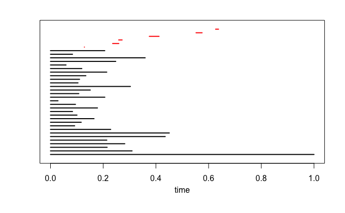

```r
diag_Eucl=ripsDiag(X = data, maxdimension = 1, maxscale = 1, dist = "euclidean", library = "Dionysus", location = TRUE)
plot(diag_Eucl[["diagram"]], barcode = TRUE)
```

Computing the barcode for the Vietoris-Rips complex of the socioeconomic space with the new Graph Distance that we have defined.

```r
diag=ripsDiag(X=graph_dist, maxdimension = 1, maxscale = 2, dist = "arbitrary", library = "Dionysus", location = TRUE, printProgress = TRUE)
```

```
# Generated complex of size: 1523

|----|----|----|----|----|----|----|----|----|----|
# Persistence timer: Elapsed time [ 0.037520 ] seconds
```

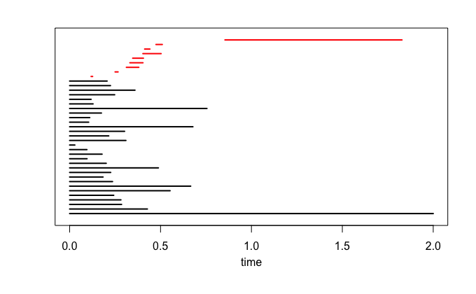

```r
plot(diag[["diagram"]], barcode=TRUE)
```

```r
diag_Eucl
```

[output not shown]

```r
diag
```

[output not shown]

Generating the Vietoris-Rips Filtration of the socioeconomic space with the Euclidean distance.

```r
filt_Eucl=ripsFiltration(X = data, maxdimension = 1, maxscale = 1, dist = "euclidean", library = "Dionysus", printProgress = TRUE)
```

```
# Generated complex of size: 4136
```

Order of appearance of the 1-simplices.

```r
edges=vector(mode="list", length = length(filt_Eucl$cmplx))
for (i in 1:length(filt_Eucl$cmplx)){
  if (length(filt_Eucl$cmplx[[i]])==2){
    edges[i]=list(filt_Eucl$cmplx[[i]])
  }
  else{
    edges[i]=list(0)
  }
}
```

Writing the above information.

```r
#write.list(edges, file = "edges_order_of_appearance_4_indicators.csv")
#write.list(list(filt_Eucl$values), file = "edges_values_4_indicators.csv")
```

Generating Vietoris-Rips complex of the socioeconomic space with the Graph distance.

```r
filt=ripsFiltration(X=graph_dist, maxdimension = 1, maxscale = 2, dist = "arbitrary", library = "Dionysus", printProgress = TRUE)
```

```
# Generated complex of size: 1523
```

Naming the states according to their index numbers in the dataset.

```r
state_name_index=c("1"="AP", "2"="AR", "3"="AS", "4"="BR", "5"="CG", "6"="DL", "7"="GA", "8"="GJ", "9"="HR", "10"="HP", "11"="JK", "12"="JH", "13"="KA", "14"="KL", "15"="MP", "16"="MH", "17"="MN", "18"="ML", "19"="MZ", "20"="NL", "21"="OD", "22"="PB", "23"="RJ", "24"="SK", "25"="TN", "26"="TS", "27"="TR", "28"="UP", "29"="UK", "30"="WB")
```

Plotting how the states get connected by 1-simplices as the values of $\epsilon$ increases. This is according to the Euclidean distance.

```r
Evolve_Eucl=function(filt_value){
evol_Eucl=matrix(0, nrow=nrow(graph_dist), ncol=ncol(graph_dist))
temp=which(filt_Eucl$values<filt_value)
for (i in nrow(graph_dist):max(temp)){
  if (length(filt_Eucl$cmplx[[i]])==2){
  evol_Eucl[filt_Eucl$cmplx[[i]][1], filt_Eucl$cmplx[[i]][2]]=1
  evol_Eucl[filt_Eucl$cmplx[[i]][2], filt_Eucl$cmplx[[i]][1]]=1
  }
  else{
    next
  }
}
g=graph_from_adjacency_matrix(evol_Eucl, mode = "undirected")
V(g)$label = state_name_index

plot(g, vertex.size=20, edge.width=2, main=filt_value)

}
```

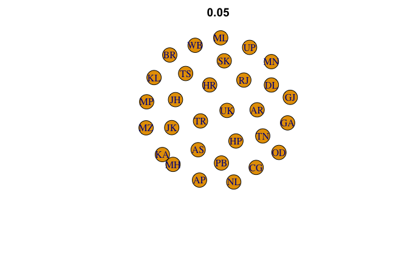

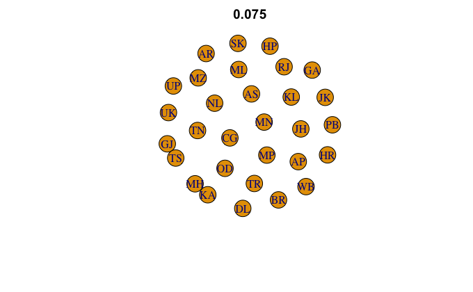

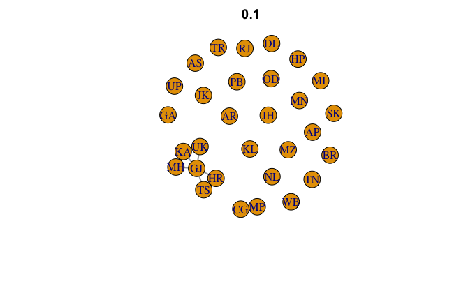

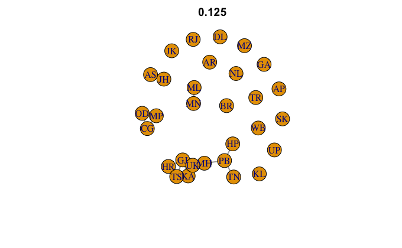

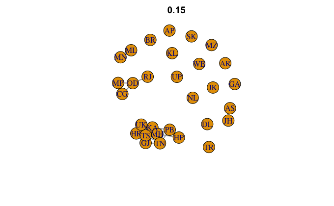

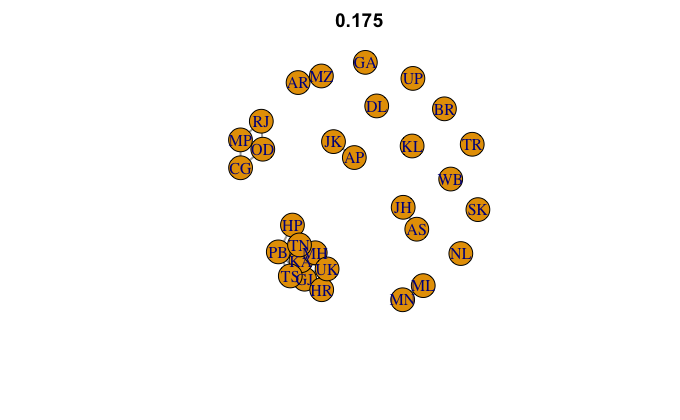

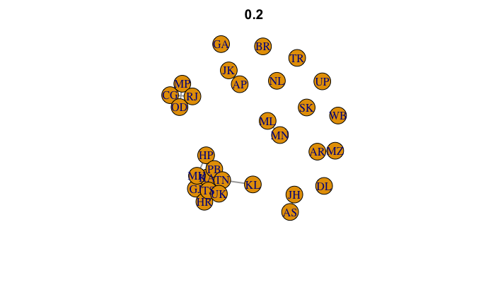

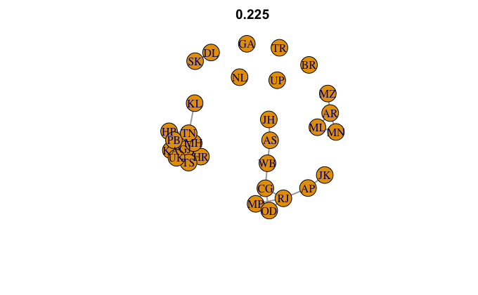

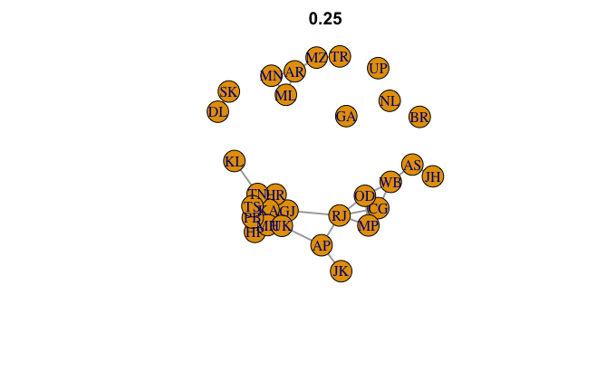

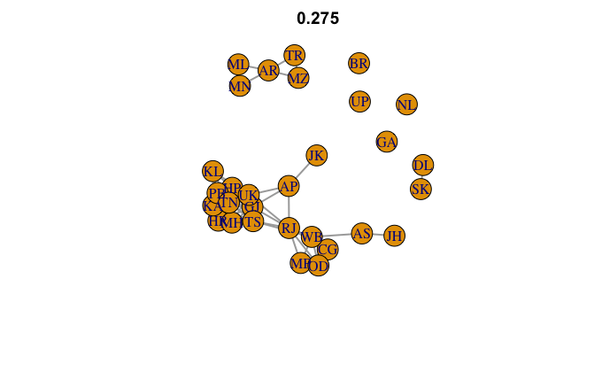

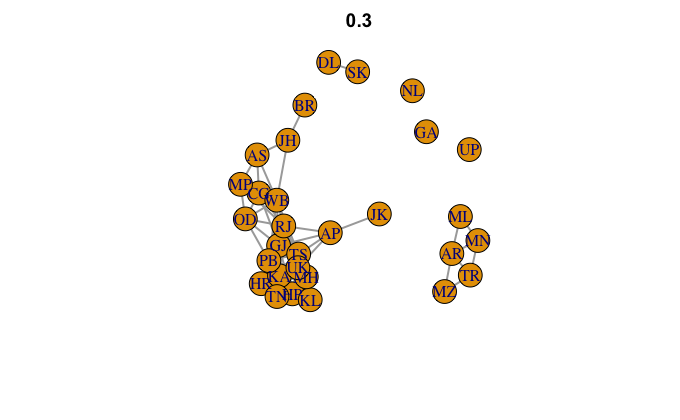

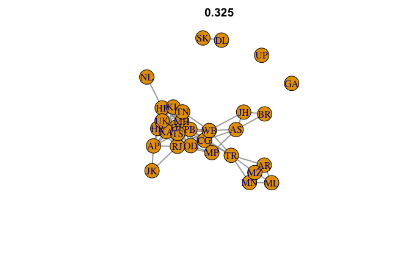

[7 more figures not shown]

```r
for (i in seq(0.05,0.5, by=0.025)){
  Evolve_Eucl(i)
}
```

```r
Evolve=function(filt_value){
evol=matrix(0, nrow=nrow(graph_dist), ncol=ncol(graph_dist))
temp=which(filt$values<filt_value)
for (i in nrow(graph_dist):max(temp)){
  if (length(filt$cmplx[[i]])==2){
  evol[filt$cmplx[[i]][1], filt$cmplx[[i]][2]]=1
  evol[filt$cmplx[[i]][2], filt$cmplx[[i]][1]]=1
  }
  else{
    next
  }
}
g=graph_from_adjacency_matrix(evol, mode = "undirected")
V(g)$label = state_name_index

plot(g, vertex.size=20, edge.width=2, main=filt_value)

}
```

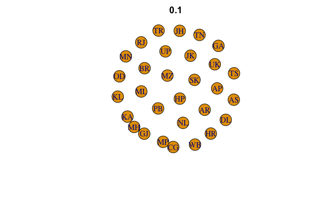

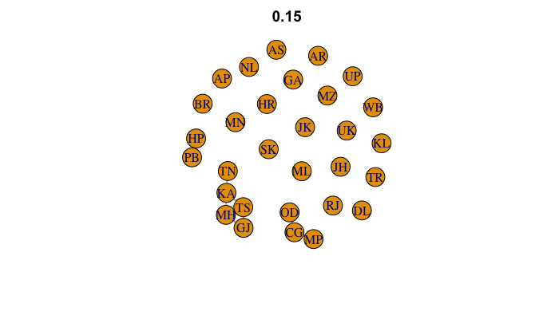

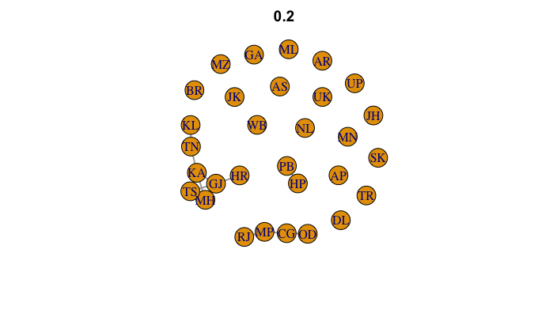

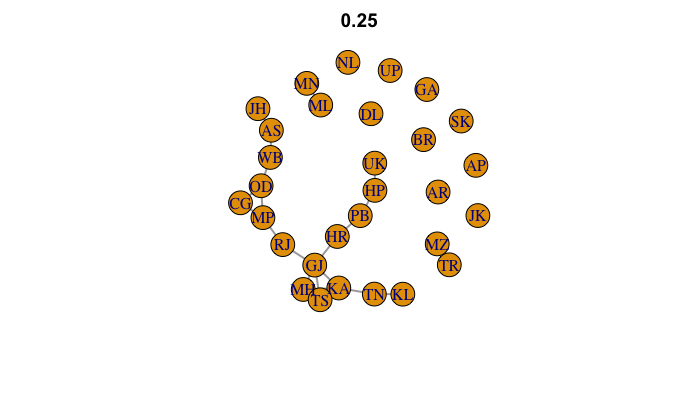

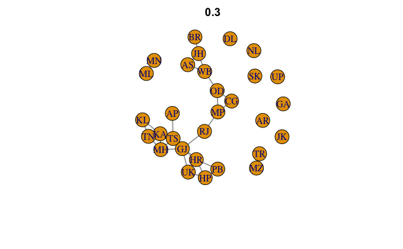

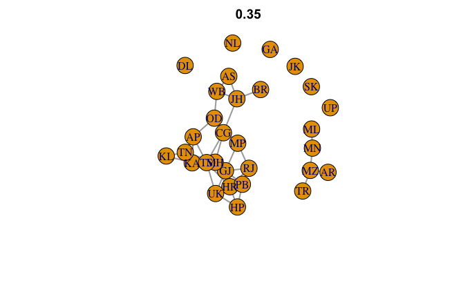

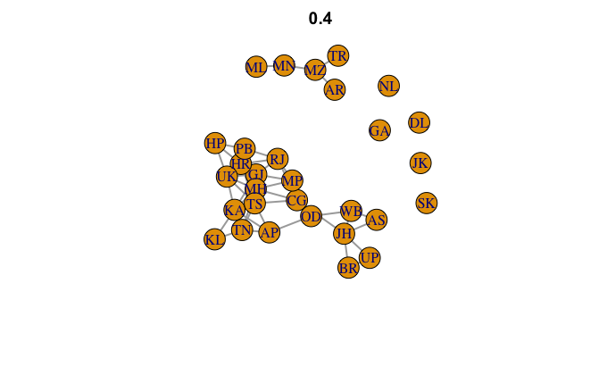

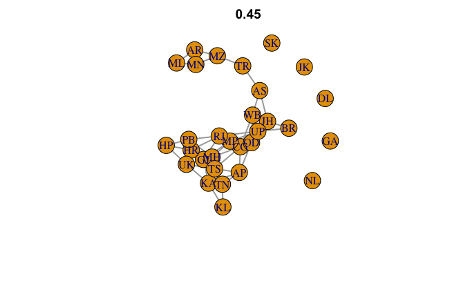

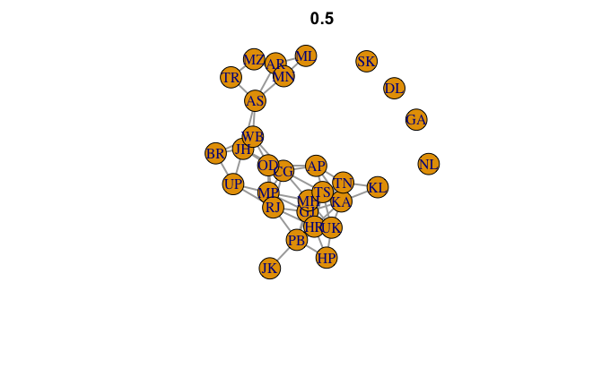

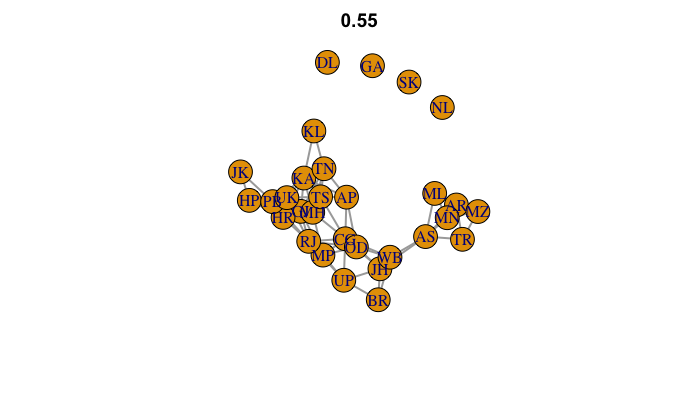

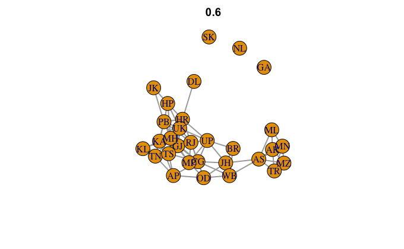

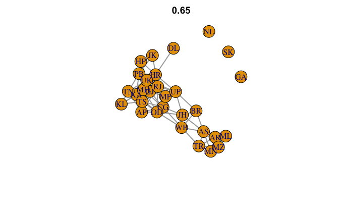

[3 more figures not shown]

```r
for (i in seq(0.1,0.8, by=0.05)){
  Evolve(i)
}
```